# Housing Price Model

Anurag Nepal

2026-10-04

# Background

# Setup

```r
raw_housing_df <- read.csv("housing_data.csv")

raw_housing_df$renovated <- as.factor(raw_housing_df$renovated)

split_indices <- createDataPartition(raw_housing_df$price, p = 0.8, list = FALSE)
housing_train <- raw_housing_df[split_indices, ]
housing_test <- raw_housing_df[-split_indices, ]
```

# Method

## Exploratory analysis

I started with the structure of the training data and where the missing values sit.

```r
summary(housing_train)
```

```
##    size_sqft       bedrooms          age           distance_city
##  Min.   : 318   Min.   :0.000   Min.   :  0.0982   Min.   : 1.100
##  1st Qu.:1488   1st Qu.:3.000   1st Qu.:  6.4252   1st Qu.: 8.409
##  Median :1812   Median :4.000   Median : 15.0245   Median :15.182
##  Mean   :1811   Mean   :3.595   Mean   : 20.9158   Mean   :15.164
##  3rd Qu.:2121   3rd Qu.:4.000   3rd Qu.: 29.5264   3rd Qu.:21.501
##  Max.   :3783   Max.   :8.000   Max.   :153.2968   Max.   :29.930
##  NA's   :15                     NA's   :15
##    crime_rate        renovated     price        price_per_sqft
##  Min.   : 0.003682   0:279     Min.   : 12023   Min.   : 23.1
##  1st Qu.: 1.334231   1:121     1st Qu.:227639   1st Qu.:144.6
##  Median : 3.276604             Median :292352   Median :162.1
##  Mean   : 4.983183             Mean   :295020   Mean   :164.4
##  3rd Qu.: 6.992979             3rd Qu.:347484   3rd Qu.:183.4
##  Max.   :27.816081             Max.   :961212   Max.   :455.7
##                                                 NA's   :15
```

```r
na_summary <- data.frame(Missing_Count = colSums(is.na(housing_train)))
knitr::kable(na_summary, caption = "Missing Values by Feature")
```

Missing Values by Feature

|  | Missing_Count |
| --- | --- |
| size_sqft | 15 |
| bedrooms | 0 |
| age | 15 |
| distance_city | 0 |
| crime_rate | 0 |
| renovated | 0 |
| price | 0 |
| price_per_sqft | 15 |

Missing values show up in a few predictors (`size_sqft`, `age`, `price_per_sqft`). Dropping every incomplete row would throw away a big chunk of training data, so imputation is on the table. Before deciding anything, I checked whether the missingness looked random.

```r
mcar_result <- mcar_test(raw_housing_df)
print(mcar_result)
```

```
## # A tibble: 1 x 4
##   statistic    df p.value missing.patterns
##       <dbl> <dbl>   <dbl>            <int>
## 1      16.5    13   0.223                3
```

Little’s MCAR test came back with p = 0.223, so I cannot reject the idea that values are missing completely at random. That matters later: if missingness carries no signal, dropping rows costs little and imputing adds nothing.

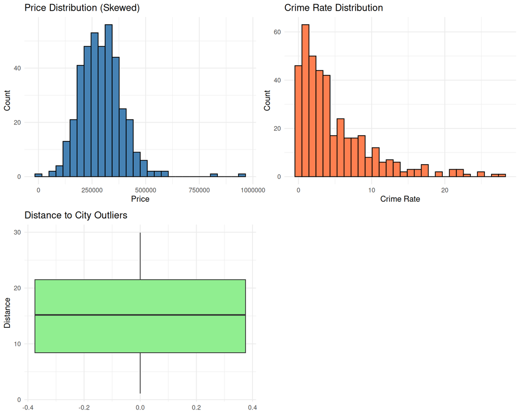

```r
plot_price_dist <- ggplot(housing_train, aes(x = price)) +
  geom_histogram(bins = 30, fill = "steelblue", color = "black") +
  theme_minimal() +
  labs(title = "Price Distribution (Skewed)", x = "Price", y = "Count")

plot_crime_dist <- ggplot(housing_train, aes(x = crime_rate)) +
  geom_histogram(bins = 30, fill = "coral", color = "black") +
  theme_minimal() +
  labs(title = "Crime Rate Distribution", x = "Crime Rate", y = "Count")

plot_dist_outliers <- ggplot(housing_train, aes(y = distance_city)) +
  geom_boxplot(fill = "lightgreen") +
  theme_minimal() +
  labs(title = "Distance to City Outliers", y = "Distance")

grid.arrange(plot_price_dist, plot_crime_dist, plot_dist_outliers, ncol=2)
```

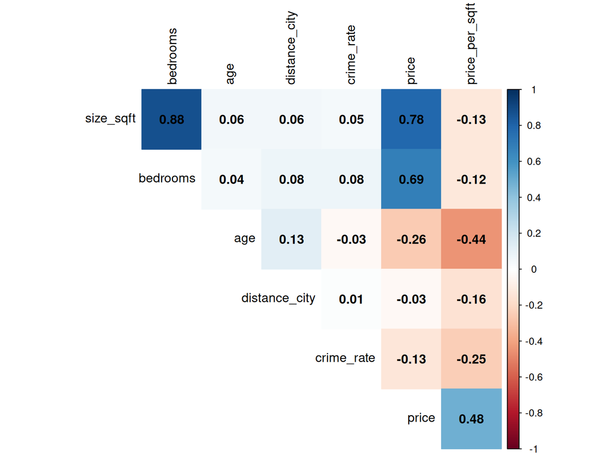

```r
numeric_subset <- housing_train %>% dplyr::select_if(is.numeric)
correlation_matrix <- cor(numeric_subset, use = "complete.obs")

corrplot(correlation_matrix, method = "color", type = "upper",
         addCoef.col = "black", tl.col = "black", diag = FALSE)
```

That gave me the preprocessing plan:

1. **Drop the leakage.** Remove `price_per_sqft`.
2. **Handle missing values.** Median for numbers, mode for categories, plus missingness indicators in one pipeline to test whether the missingness itself carries signal.
3. **Handle outliers.** Cap at the 5th and 95th percentiles rather than deleting rows.
4. **Transform and scale.** Standardize predictors for Ridge and Lasso, and log-transform the skewed `price` and `crime_rate`.

## The five pipelines

Every pipeline below is trained with 10-fold cross-validation and scored on the held-out test set. Two helpers keep the bookkeeping straight: one pulls the best CV row out of each caret fit, and one scores the test set. The imputation helper always uses training-set statistics, so the test set never leaks into training.

```r
# Cross-Validation Configuration
cv_control <- trainControl(method = "cv", number = 10)

# Summary function for Log-transformed models (Back-transforms to original scale)
exp_summary <- function(data, lev = NULL, model = NULL) {
  obs <- exp(data$obs)
  pred <- exp(data$pred)
  c(RMSE = RMSE(pred, obs), Rsquared = R2(pred, obs), MAE = MAE(pred, obs))
}

cv_control_log <- trainControl(method = "cv", number = 10, summaryFunction = exp_summary)

# Storage for results
performance_metrics_storage <- list()
test_metrics_storage <- list()
```

```r
# Extract CV performance from caret object
extract_performance <- function(model_obj, pipeline_label, model_type) {
  best_row <- model_obj$results[which.min(model_obj$results$RMSE), ]
  data.frame(
    Pipeline = pipeline_label,
    Model = model_type,
    RMSE = paste0(round(best_row$RMSE, 2), " (± ", round(best_row$RMSESD, 2), ")"),
    MAE = paste0(round(best_row$MAE, 2), " (± ", round(best_row$MAESD, 2), ")"),
    RMSE_Num = best_row$RMSE
  )
}

# Calculate performance on unseen test set
get_test_perf <- function(model_obj, test_data, label, model_type, is_log = FALSE) {
  preds <- predict(model_obj, newdata = test_data)
  obs <- test_data$price
  if(is_log) preds <- exp(preds)

  data.frame(
    Pipeline = label,
    Model = model_type,
    Test_RMSE = round(RMSE(preds, obs), 2),
    Test_MAE = round(MAE(preds, obs), 2)
  )
}

# Unified Imputation Function (Ensures Test uses Training stats)
impute_data <- function(target_df, reference_df) {
  res_df <- target_df
  for(nm in names(res_df)) {
    if(is.numeric(res_df[[nm]])) {
      res_df[[nm]][is.na(res_df[[nm]])] <- median(reference_df[[nm]], na.rm = TRUE)
    } else {
      mode_val <- names(sort(table(reference_df[[nm]]), decreasing = TRUE))[1]
      res_df[[nm]][is.na(res_df[[nm]])] <- mode_val
    }
  }
  return(res_df)
}
```

### Pipeline 0: baseline

Drop the leakage variable and any row with a missing value. No scaling, no transformations. This is the complete-case OLS baseline everything else has to beat.

```r
housing_train_clean <- housing_train %>% dplyr::select(-price_per_sqft)
housing_test_clean  <- housing_test %>% dplyr::select(-price_per_sqft)

train_p0 <- na.omit(housing_train_clean)
test_p0  <- na.omit(housing_test_clean)

# Train
fit_p0_ols   <- train(price ~ ., data = train_p0, method = "lm", trControl = cv_control)
fit_p0_ridge <- train(price ~ ., data = train_p0, method = "glmnet",
                      tuneGrid = expand.grid(alpha = 0, lambda = seq(0.1, 10, length=5)),
                      trControl = cv_control)

performance_metrics_storage[[1]] <- extract_performance(fit_p0_ols, "P0_Baseline", "OLS")
performance_metrics_storage[[2]] <- extract_performance(fit_p0_ridge, "P0_Baseline", "Ridge")
test_metrics_storage[[1]] <- get_test_perf(fit_p0_ols, test_p0, "P0_Baseline", "OLS")
test_metrics_storage[[2]] <- get_test_perf(fit_p0_ridge, test_p0, "P0_Baseline", "Ridge")
```

### Pipeline 1: imputation

Keep all rows by filling missing numbers with the median and missing categories with the mode. Still no scaling.

```r
train_p1 <- impute_data(housing_train_clean, housing_train_clean)
test_p1  <- impute_data(housing_test_clean, housing_train_clean)

# Train
fit_p1_ols   <- train(price ~ ., data = train_p1, method = "lm", trControl = cv_control)
fit_p1_ridge <- train(price ~ ., data = train_p1, method = "glmnet",
                      tuneGrid = expand.grid(alpha = 0, lambda = seq(0.1, 10, length=5)),
                      trControl = cv_control)

# Evaluate
performance_metrics_storage[[3]] <- extract_performance(fit_p1_ols, "P1_Imputed", "OLS")
performance_metrics_storage[[4]] <- extract_performance(fit_p1_ridge, "P1_Imputed", "Ridge")
test_metrics_storage[[3]] <- get_test_perf(fit_p1_ols, test_p1, "P1_Imputed", "OLS")
test_metrics_storage[[4]] <- get_test_perf(fit_p1_ridge, test_p1, "P1_Imputed", "Ridge")
```

### Pipeline 2: imputation plus missingness indicators

Same as Pipeline 1, but with a binary column flagging where each missing value was before imputation. If missingness carries signal about price, this should pick it up. Near-zero-variance columns are dropped.

```r
# Add Indicators
add_indicators <- function(df) mutate(df, across(everything(), is.na, .names = "na_{.col}"))

train_p2_raw <- add_indicators(housing_train_clean)
test_p2_raw  <- add_indicators(housing_test_clean)

# 2. Impute
train_p2_imputed <- impute_data(train_p2_raw, train_p2_raw)
test_p2_imputed  <- impute_data(test_p2_raw, train_p2_raw)

# This identifies columns where all values are the same (e.g., all FALSE)
nzv_cols <- nearZeroVar(train_p2_imputed)

if(length(nzv_cols) > 0) {
  train_p2 <- train_p2_imputed[, -nzv_cols]
  test_p2  <- test_p2_imputed[, -nzv_cols]
} else {
  train_p2 <- train_p2_imputed
  test_p2  <- test_p2_imputed
}

# Train
fit_p2_ols   <- train(price ~ ., data = train_p2, method = "lm", trControl = cv_control)
fit_p2_ridge <- train(price ~ ., data = train_p2, method = "glmnet",
                      tuneGrid = expand.grid(alpha = 0, lambda = seq(0.1, 10, length=5)),
                      trControl = cv_control)

# Evaluate
performance_metrics_storage[[5]] <- extract_performance(fit_p2_ols, "P2_Indicators", "OLS")
performance_metrics_storage[[6]] <- extract_performance(fit_p2_ridge, "P2_Indicators", "Ridge")
test_metrics_storage[[5]] <- get_test_perf(fit_p2_ols, test_p2, "P2_Indicators", "OLS")
test_metrics_storage[[6]] <- get_test_perf(fit_p2_ridge, test_p2, "P2_Indicators", "Ridge")
```

### Pipeline 3: normalization

Standardize the numeric predictors using training-set means and standard deviations, then fit Ridge and Lasso. Regularized models need this so the penalty treats features fairly.

```r
# Identify numeric columns (excluding price)
num_cols <- names(train_p2)[sapply(train_p2, is.numeric) & names(train_p2) != "price"]

# Calculate scaling parameters from train
train_means <- colMeans(train_p2[, num_cols])
train_sds   <- apply(train_p2[, num_cols], 2, sd)

# Scale both
train_p3 <- train_p2
test_p3  <- test_p2
train_p3[num_cols] <- scale(train_p2[num_cols], center = train_means, scale = train_sds)
test_p3[num_cols]  <- scale(test_p2[num_cols], center = train_means, scale = train_sds)

# Train
fit_p3_ridge <- train(price ~ ., data = train_p3, method = "glmnet",
                      tuneGrid = expand.grid(alpha = 0, lambda = seq(0.1, 10, length=5)),
                      trControl = cv_control)
fit_p3_lasso <- train(price ~ ., data = train_p3, method = "glmnet",
                      tuneGrid = expand.grid(alpha = 1, lambda = seq(0.1, 10, length=5)),
                      trControl = cv_control)

# Evaluate
performance_metrics_storage[[7]] <- extract_performance(fit_p3_ridge, "P3_Normalized", "Ridge")
performance_metrics_storage[[8]] <- extract_performance(fit_p3_lasso, "P3_Normalized", "Lasso")
test_metrics_storage[[7]] <- get_test_perf(fit_p3_ridge, test_p3, "P3_Normalized", "Ridge")
test_metrics_storage[[8]] <- get_test_perf(fit_p3_lasso, test_p3, "P3_Normalized", "Lasso")
```

### Pipeline 4: full preprocessing

Everything at once: imputation, indicators, log-transforms of price and `crime_rate`, Winsorization at the 5th and 95th percentiles using training quantiles, then re-standardization. The log-scale models are scored back on the original dollar scale so the comparison stays fair.

```r
# Log Transforms
train_p4 <- train_p2 %>% mutate(price = log(price), crime_rate = log(crime_rate + 1))
test_p4  <- test_p2  %>% mutate(crime_rate = log(crime_rate + 1)) # Price stays original for get_test_perf

# Capping (Winsorization) using Training Quantiles
for(nm in num_cols) {
  qnts <- quantile(train_p4[[nm]], probs = c(.05, .95), na.rm = TRUE)
  train_p4[[nm]] <- pmin(pmax(train_p4[[nm]], qnts[1]), qnts[2])
  test_p4[[nm]]  <- pmin(pmax(test_p4[[nm]], qnts[1]), qnts[2])
}

# Re-scale based on the new P4 training distributions
train_p4_means <- colMeans(train_p4[, num_cols])
train_p4_sds   <- apply(train_p4[, num_cols], 2, sd)

train_p4[num_cols] <- scale(train_p4[num_cols], center = train_p4_means, scale = train_p4_sds)
test_p4[num_cols]  <- scale(test_p4[num_cols], center = train_p4_means, scale = train_p4_sds)

# Train
fit_p4_ridge <- train(price ~ ., data = train_p4, method = "glmnet",
                      tuneGrid = expand.grid(alpha = 0, lambda = seq(0.001, 0.1, length=5)),
                      trControl = cv_control_log)
fit_p4_lasso <- train(price ~ ., data = train_p4, method = "glmnet",
                      tuneGrid = expand.grid(alpha = 1, lambda = seq(0.001, 0.1, length=5)),
                      trControl = cv_control_log)

# Evaluate
performance_metrics_storage[[9]] <- extract_performance(fit_p4_ridge, "P4_Full_Processing", "Ridge")
performance_metrics_storage[[10]] <- extract_performance(fit_p4_lasso, "P4_Full_Processing", "Lasso")

test_metrics_storage[[9]] <- get_test_perf(fit_p4_ridge, test_p4, "P4_Full_Processing", "Ridge", is_log = TRUE)
test_metrics_storage[[10]] <- get_test_perf(fit_p4_lasso, test_p4, "P4_Full_Processing", "Lasso", is_log = TRUE)
```

# Results

The cross-validated comparison and the held-out test scores tell the same story.

```r
final_results <- bind_rows(performance_metrics_storage)
knitr::kable(final_results %>% dplyr::select(-RMSE_Num), caption = "Final Model Comparison")
```

Final Model Comparison

| Pipeline | Model | RMSE | MAE |
| --- | --- | --- | --- |
| P0_Baseline | OLS | 45814.87 (± 18091.58) | 31707.57 (± 6125.63) |
| P0_Baseline | Ridge | 46006.74 (± 20310.99) | 32668.45 (± 6990.74) |
| P1_Imputed | OLS | 50966.55 (± 26322.97) | 33785.18 (± 8091.42) |
| P1_Imputed | Ridge | 52966.87 (± 22409.28) | 34312.07 (± 6827.17) |
| P2_Indicators | OLS | 52885.15 (± 21853.99) | 34117.72 (± 6305.89) |
| P2_Indicators | Ridge | 52898.24 (± 23144.2) | 34616.26 (± 7517.24) |
| P3_Normalized | Ridge | 52897.8 (± 22669.91) | 34422.23 (± 6500.04) |
| P3_Normalized | Lasso | 50165.97 (± 29013.94) | 34042.62 (± 10690.89) |
| P4_Full_Processing | Ridge | 57576.54 (± 22524.34) | 38944.28 (± 8347.26) |
| P4_Full_Processing | Lasso | 57715.22 (± 20603.1) | 38836.25 (± 6111.35) |

```r
test_results_final <- bind_rows(test_metrics_storage)
knitr::kable(test_results_final, caption = "Model Performance on Unseen Test Data")
```

Model Performance on Unseen Test Data

| Pipeline | Model | Test_RMSE | Test_MAE |
| --- | --- | --- | --- |
| P0_Baseline | OLS | 63202.49 | 36907.90 |
| P0_Baseline | Ridge | 65040.12 | 38098.34 |
| P1_Imputed | OLS | 63571.48 | 38038.64 |
| P1_Imputed | Ridge | 65069.86 | 39078.81 |
| P2_Indicators | OLS | 63571.48 | 38038.64 |
| P2_Indicators | Ridge | 65069.86 | 39078.81 |
| P3_Normalized | Ridge | 65069.86 | 39078.81 |
| P3_Normalized | Lasso | 63466.54 | 37947.23 |
| P4_Full_Processing | Ridge | 71259.84 | 43344.54 |
| P4_Full_Processing | Lasso | 70895.78 | 43256.51 |

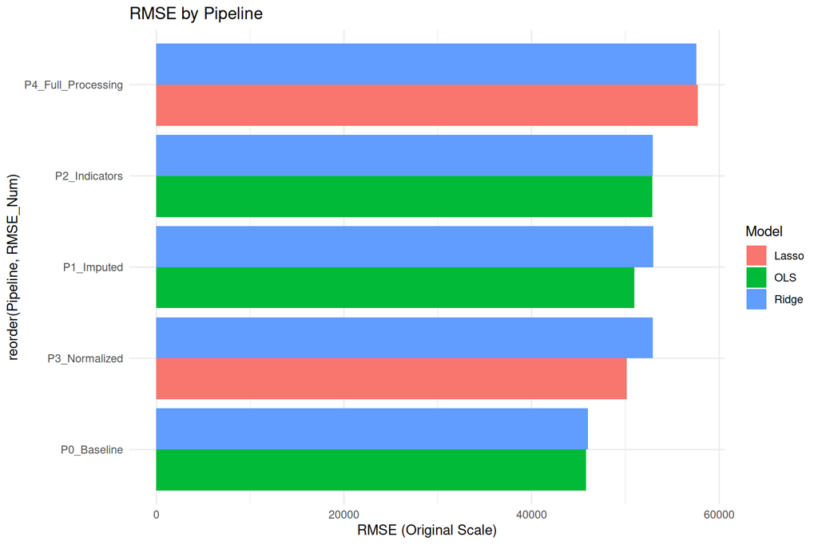

```r
ggplot(final_results, aes(x = reorder(Pipeline, RMSE_Num), y = RMSE_Num, fill = Model)) +
  geom_bar(stat = "identity", position="dodge") +
  coord_flip() + theme_minimal() + labs(title = "RMSE by Pipeline", y = "RMSE (Original Scale)")
```

The headline results:

- **The plain baseline won.** Pipeline 0 OLS had the lowest CV RMSE (45,814.87) and MAE (31,707.57), and stayed best on the test set (RMSE 63,202.49, MAE 36,907.90). Every fancier pipeline did worse.
- **Complete-case analysis did not hurt.** Dropping incomplete rows beat all imputation. That makes sense given the MCAR test: with missingness completely at random, dropping rows leaves a smaller but unbiased sample, while median/mode imputation compresses variance and adds noise. CV RMSE rose from ~46k (P0) to ~51k (P1).
- **Missingness indicators added nothing.** Going from P1 to P2 pushed OLS RMSE from ~51k to ~53k. The indicators carried no signal about price, which is exactly what MCAR predicts.
- **Normalization did not save the regularized models.** It helped Lasso slightly relative to the imputation pipelines, but everything stayed worse than the baseline. In housing, large-scale features like square footage carry the strongest signal, and standardizing mutes that natural importance while the penalty bites harder.
- **Winsorizing hurt the most.** Pipeline 4 came in worst overall at ~58k RMSE. The extremes here are informative: genuine luxury homes with genuinely high prices. Capping them forced systematic under-prediction at the top end.
- **The log transform backfired on the dollar scale.** Back-transforming small log-scale errors into dollars blew them up, pushing MAE to ~39k. The price relationship in this data looks additive, not multiplicative.

# Takeaway

Preprocessing is not free, and on this data most of it was harmful. Because the missingness was completely at random, the simplest thing, dropping incomplete rows and fitting OLS, beat every imputation, scaling, and transformation I tried. The two mistakes to avoid generalize: keeping a leakage variable like `price_per_sqft` would let the model cheat off the target’s own formula, and computing imputations or scaling factors before the train/test split would leak test information into training. Both inflate performance estimates that do not survive contact with new data.

# Back-transformation sensitivity

[output not shown]

Test RMSE in dollars. Smearing factors 1.0258 (Ridge) and 1.0255 (Lasso); the correction moves RMSE slightly the wrong way, and the pipeline ranking is unchanged. An honest null: the bias correction does not rescue the log pipeline, and the original comparison stands.

**Data provenance.** No source is cited for the housing data, and the values look generated (fractional square footage, sub-day ages), so this analysis is treated as synthetic. Absolute error levels should not be quoted as real-world figures.